# HPLC: compare standards, compute linear module

Author

Fermlab

# Introduction

This notebook compares the peak areas from HPLC standards .lcd files using ChromConverter. The HPLC files include data from 3 channels (below). For these analyses, we will focus only on the data from detector B (RID).

1. Detector A-Ch1: UV/VIS SPD-20A detector at 260 nm.
2. Detector A-Ch2: UV/VIS SPD-20A detector at 210 nm. Acids (ie acetate) are visible using channel 2.
3. Detector B: Refractive index RID-10A.

We compare the chromatograms for 5 concentrations of metabolites (STD1-5) (see table below). We will calculate peak areas for each file type and plot the linearity of the standard curves. The output is a file containing parameters of the linear models (slope, intercept) to calculate metabolite concentrations from the peak areas.

## File IO

Files used by this script.

```r
# sample information file
info.file = "/home/tolonen/Github/actolonen/Public/Analysis_Lab/Metabolites/HPLC/Data/information_HPLC.xlsx";

# input directory of .lcd files
lcd.input.dir = "/home/tolonen/Github/actolonen/Public/Analysis_Lab/Metabolites/HPLC/Data/LCD_LabSolutions";

# output directory of .txt files
txt.output.dir = "/home/tolonen/Github/actolonen/Public/Analysis_Lab/Metabolites/HPLC/Data/TXT_ChromConverter";

# output file of linear model
table.out = "/home/tolonen/Github/actolonen/Public/Analysis_Lab/Metabolites/HPLC/Data/standards_regressions.tsv";
```

Metabolite concentrations in standards samples.

```r
standards = read_excel(info.file, sheet = "Standards", col_names = TRUE);

table.standards = kable(standards, caption = "Table: Metabolite concentrations in standards");
table.standards
```

Table: Metabolite concentrations in standards

| File | Metabolite | mM |
| --- | --- | --- |
| STD1-100-1.lcd | Acetate | 50.000000 |
| STD1-100-1.lcd | Ethanol | 342.500000 |
| STD1-100-1.lcd | Lactate | 50.000000 |
| STD1-100-1.lcd | Glucose | 27.775000 |
| STD1-100-1.lcd | Cellobiose | 27.775000 |
| STD1-50-1.lcd | Acetate | 25.000000 |
| STD1-50-1.lcd | Ethanol | 171.250000 |
| STD1-50-1.lcd | Lactate | 25.000000 |
| STD1-50-1.lcd | Glucose | 13.887500 |
| STD1-50-1.lcd | Cellobiose | 13.887500 |
| STD1-25-1.lcd | Acetate | 12.500000 |
| STD1-25-1.lcd | Ethanol | 85.625000 |
| STD1-25-1.lcd | Lactate | 12.500000 |
| STD1-25-1.lcd | Glucose | 6.943750 |
| STD1-25-1.lcd | Cellobiose | 6.943750 |
| STD1-125-1.lcd | Acetate | 6.250000 |
| STD1-125-1.lcd | Ethanol | 42.812500 |
| STD1-125-1.lcd | Lactate | 6.250000 |
| STD1-125-1.lcd | Glucose | 3.471875 |
| STD1-125-1.lcd | Cellobiose | 3.471875 |
| STD1-625-1.lcd | Acetate | 3.125000 |
| STD1-625-1.lcd | Ethanol | 21.406250 |
| STD1-625-1.lcd | Lactate | 3.125000 |
| STD1-625-1.lcd | Glucose | 1.735937 |
| STD1-625-1.lcd | Cellobiose | 1.735937 |
| STD1-100-2.lcd | Acetate | 50.000000 |
| STD1-100-2.lcd | Ethanol | 342.500000 |
| STD1-100-2.lcd | Lactate | 50.000000 |
| STD1-100-2.lcd | Glucose | 27.775000 |
| STD1-100-2.lcd | Cellobiose | 27.775000 |
| STD1-50-2.lcd | Acetate | 25.000000 |
| STD1-50-2.lcd | Ethanol | 171.250000 |
| STD1-50-2.lcd | Lactate | 25.000000 |
| STD1-50-2.lcd | Glucose | 13.887500 |
| STD1-50-2.lcd | Cellobiose | 13.887500 |
| STD1-25-2.lcd | Acetate | 12.500000 |
| STD1-25-2.lcd | Ethanol | 85.625000 |
| STD1-25-2.lcd | Lactate | 12.500000 |
| STD1-25-2.lcd | Glucose | 6.943750 |
| STD1-25-2.lcd | Cellobiose | 6.943750 |
| STD1-125-2.lcd | Acetate | 6.250000 |
| STD1-125-2.lcd | Ethanol | 42.812500 |
| STD1-125-2.lcd | Lactate | 6.250000 |
| STD1-125-2.lcd | Glucose | 3.471875 |
| STD1-125-2.lcd | Cellobiose | 3.471875 |
| STD1-625-2.lcd | Acetate | 3.125000 |
| STD1-625-2.lcd | Ethanol | 21.406250 |
| STD1-625-2.lcd | Lactate | 3.125000 |
| STD1-625-2.lcd | Glucose | 1.735937 |
| STD1-625-2.lcd | Cellobiose | 1.735937 |

# Functions

## Calc peak areas

Calculate peak areas for a metabolite. Returns list: chromatogram peaks for all samples, peak areas for all samples.

```r
calc_peakAreas = function(peak.start, peak.end, data.all)
{
#  get list of samples
file.list = unique(data.all$File);

# declare dataframes for peaks and areas
peaks.all = data.frame(Minutes = double(),
                           Intensity = double(),
                           File = character(),
                           Detector = character());

areas.all = data.frame(File = character(),
                       Area = double(),
                       Detector = character());

for (SampleID in file.list) # foreach standards sample
{

# calc background as mode measurement
data.temp = data.all %>%
  filter(File == SampleID);
background.cc = modeest::mfv(round(data.temp$Intensity, digits = 1));

 # get chromatogram for peak
 data.peak = data.all %>%
   filter(File == SampleID) %>%
   filter(Minutes > peak.start & Minutes < peak.end);
   # separate(Sample, c("Sample", "Replicate"), sep = "-");

 peaks.all = rbind(peaks.all, data.peak);

 # calc peak areas: cc and ls
 data.temp = data.peak %>%
   mutate(Intensity_diff = Intensity - background.cc);
 my.area =AUC(data.temp$Minutes, data.temp$Intensity_diff, method='trapezoid');
 Detector = unique(data.temp$Detector);
 File = SampleID;
 area.sample = data.frame(File, my.area, Detector);
 areas.all = rbind(areas.all, area.sample);

}
# return data as a list
peakData = list(peaks.all, areas.all);
return(peakData);
}
```

# Methods

## Convert .lcd files to .txt files

ChromConverter to read .lcd files and output detector B .txt files.

```r
# get a list of .lcd files in the working directory and convert them to data.frames,
# then print the data.frmes as .txt files.

# select sample files for analysis
files.lcd = list.files(path = lcd.input.dir, pattern = ".lcd");
files.lcd.df = data.frame(files.lcd);
files.lcd.df = files.lcd.df %>%
  filter(grepl("^STD", files.lcd));
files.lcd = dplyr::pull(files.lcd.df, files.lcd);

# declare empty data.frame for all samples
chromatograms.all = data.frame(
                      Minutes = double(),
                      Intensity = double(),
                      File = character(),
                      Detector = character());

for (file in files.lcd)
{
  inputfile = paste(lcd.input.dir, file, sep = "/");
  inputfile.base = str_replace(string=file, pattern=".lcd", replacement = "");

# declare a data.fram for this sample
chromatograms.sample = data.frame(
                      Minutes = double(),
                      Intensity = double(),
                      File = character(),
                      Detector = character());

  data = read_shimadzu_lcd(
     path = inputfile,
     format_out = "data.frame",
     data_format = "long",
     read_metadata = TRUE);

  #for (detector in data) # foreach detector (data.frame) in the data list
  #{
  detector = data;
    my.instrument = attr(detector, which = "instrument");
    my.detector = attr(detector, which = "detector");
    my.wavelength = attr(detector, which = "wavelength");
    my.detector = if_else(my.detector == "SPD-20A", true = paste(my.detector, my.wavelength, sep = " "), false = my.detector);
    detector = detector %>%
      rownames_to_column(var = "Minutes") %>%
      rename(Intensity = int) %>%
      mutate(File = file) %>%
      mutate(Detector = my.detector);
      chromatograms.sample = rbind(chromatograms.sample, detector);
  # }

chromatograms.all = rbind(chromatograms.all, chromatograms.sample);

# print out chromatogram from this sample to file
chromatogram.file = paste(inputfile.base, ".txt", sep="");
chromatogram.out = paste(txt.output.dir, chromatogram.file, sep="/");
write.table(chromatograms.sample, file = chromatogram.out, row.names=FALSE, sep="\t", col.names=TRUE);
}
```

# Results

```r
sample.list = unique(chromatograms.all$Sample);
list.chromatograms.all <- list()  # new empty list

counter = 1;
for (mysample in sample.list)
{
 data.plot = chromatograms.all %>%
   filter(Sample == mysample) %>%
   mutate(Minutes = as.numeric(Minutes));

 myplot = ggplot(data.plot, aes(x=Minutes, y=Intensity)) +
  ggtitle(mysample)+
  geom_point(size=0.1, color = 'blue') +
  xlab("Time") +
  ylab("Intensity") +
  facet_wrap(~ Detector)+
  coord_cartesian(xlim=c(0, max(data.plot$Minutes)), ylim=c(min(data.plot$Intensity), max(data.plot$Intensity)))+
  theme_classic()+
  mytheme;

  list.chromatograms.all[[counter]] = myplot;  # add each plot into plot list
  counter = counter+1;
  grid.arrange(myplot, ncol=1);
}
 #chromatograms.all.plots = grid.arrange(grobs = list.chromatograms.all);
```

## Focus just on detector-B data for quantification

```r
data.all = chromatograms.all %>%
  filter(Detector == "RID-10A") %>%
  mutate(Minutes = as.numeric(Minutes));
```

## Metabolite concentrations

```r
# declare output table with regression information to calculate concentrations from peak
# areas in experimental samples.

# compound_mM = Slope.reg * peak.area + Intercept.reg;

regressions.out = data.frame(
    Compound = character(),
    Slope.reg = double(),
    Intercept.reg = double(),
    peak.start = double(),
    peak.end = double()
);
```

### Acetate

Calc peak areas

```r
# compound parameters
Compound = "Acetate";
peak.start = 17.7;
peak.end = 18.7;

# get the chromatogram peaks and calculate the areas for each sample
peakData = calc_peakAreas(peak.start, peak.end, data.all);
peaks.all = peakData[[1]];
areas.all = peakData[[2]];

# add standard concentrations to peak areas
standards.compound = standards %>%
  filter(Metabolite == Compound);

areas.all.concs = left_join(areas.all, standards.compound, by="File");

areas.all.concs = areas.all.concs %>%
  rename(Area = my.area);
```

Calc regressions

```r
my.lm = lm(mM ~ Area, areas.all.concs);
yint = my.lm$coefficients[1];
myslope = my.lm$coefficients[2];
myslope.text = formatC(myslope, format = "e", digits = 2);

regression.cc = data.frame(Compound, myslope, yint, peak.start, peak.end);
regressions.out = rbind(regressions.out, regression.cc);
regtext.cc = paste("mM product = ", myslope.text, "* Area + ", round(yint, 3), sep="");
```

Plot peaks

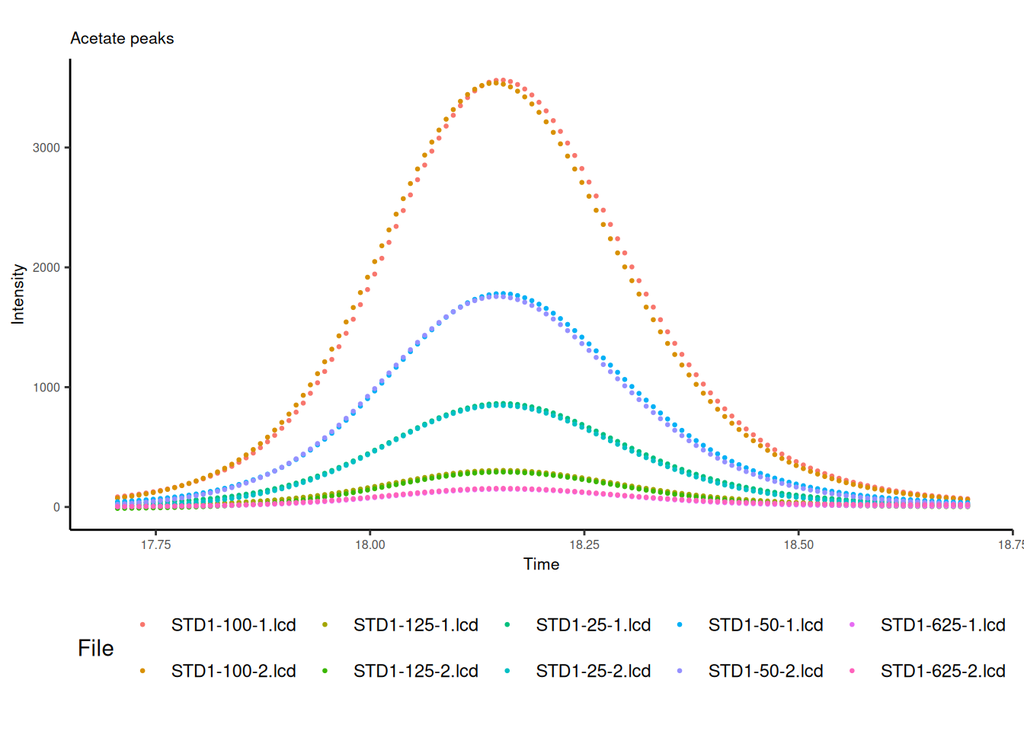

Peak areas of acetate in each of the standards samples.

```r
# plot peaks
 myplot = ggplot(peaks.all, aes(x=Minutes, y=Intensity, group=File, color=File)) +
  ggtitle(paste(Compound, " peaks", sep=""))+
  geom_point(size=0.5) +
  xlab("Time") +
  ylab("Intensity") +
  coord_cartesian(xlim=c(peak.start, peak.end), ylim=c(min(peaks.all$Intensity), max(peaks.all$Intensity)))+
  theme_classic()+
  mytheme;

myplot
```

Plot regressions

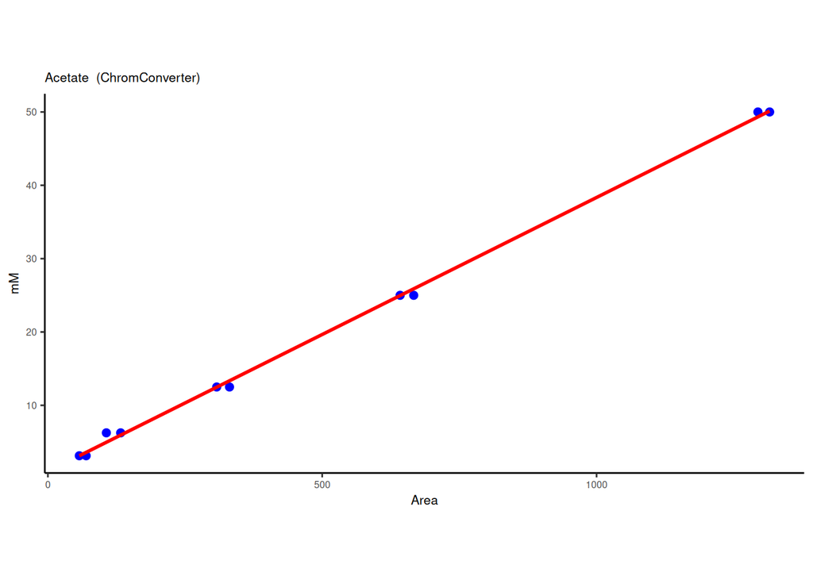

Linear regressions of peak area vs acetate concentration for all standards.

```r
# text placement
text.x = 2e3;
text.y = 5;

plot.reg.cc = ggplot(areas.all.concs, aes(x=Area, y=mM))+
  ggtitle(paste(Compound," (ChromConverter)"))+
  geom_point(size=2, color = 'blue') +
  geom_smooth(method=lm, se=FALSE, color='red', width=0.1, formula = y ~ x)+
  xlab("Area") +
  ylab("mM") +
  theme_classic() +
  geom_text(x=text.x, y=text.y, label=regtext.cc, size=2)+
  mytheme;

# print regressions
 bothplots = grid.arrange(plot.reg.cc, ncol = 1);
```

### Ethanol

Calc peak areas

```r
# compound parameters
Compound = "Ethanol";
peak.start = 25.75;
peak.end = 27.25;

# get the chromatogram peaks and calculate the areas for each sample
peakData = calc_peakAreas(peak.start, peak.end, data.all);
peaks.all = peakData[[1]];
areas.all = peakData[[2]];

# add standard concentrations to peak areas
standards.compound = standards %>%
  filter(Metabolite == Compound);

areas.all.concs = left_join(areas.all, standards.compound, by="File");

areas.all.concs = areas.all.concs %>%
  rename(Area = my.area);
```

Calc regressions

```r
my.lm = lm(mM ~ Area, areas.all.concs);
yint = my.lm$coefficients[1];
myslope = my.lm$coefficients[2];
myslope.text = formatC(myslope, format = "e", digits = 2);

regression.cc = data.frame(Compound, myslope, yint, peak.start, peak.end);
regressions.out = rbind(regressions.out, regression.cc);
regtext.cc = paste("mM product = ", myslope.text, "* Area + ", round(yint, 3), sep="");
```

Plot peaks

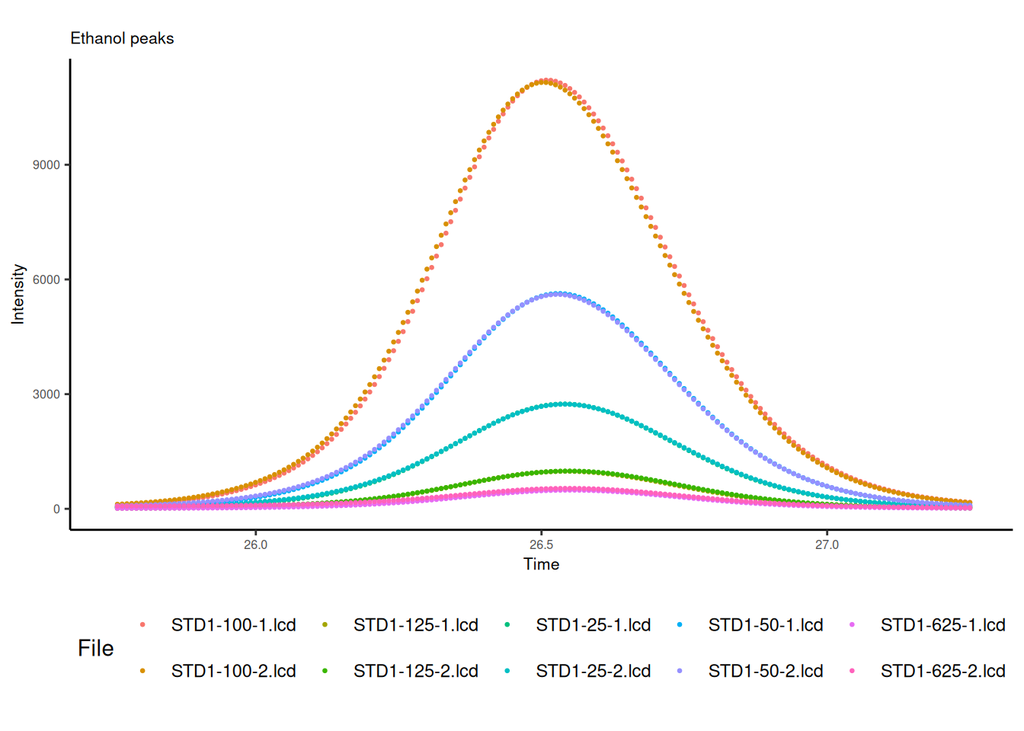

Peak areas of ethanol in each of the standards samples.

```r
# plot peaks
 myplot = ggplot(peaks.all, aes(x=Minutes, y=Intensity, group=File, color=File)) +
  ggtitle(paste(Compound, " peaks", sep=""))+
  geom_point(size=0.5) +
  xlab("Time") +
  ylab("Intensity") +
  coord_cartesian(xlim=c(peak.start, peak.end), ylim=c(min(peaks.all$Intensity), max(peaks.all$Intensity)))+
  theme_classic()+
  mytheme;

myplot
```

Plot regressions

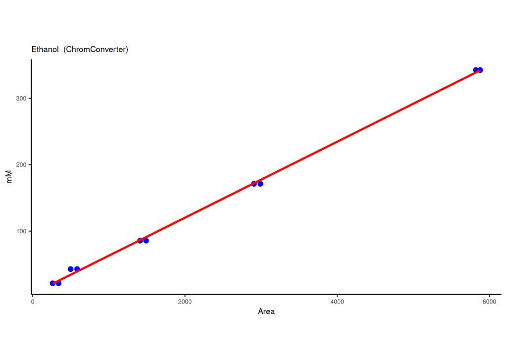

Linear regressions of peak area vs ethanol concentration for all standards.

```r
# text placement
text.x = 10e3;
text.y = 50;

plot.reg.cc = ggplot(areas.all.concs, aes(x=Area, y=mM))+
  ggtitle(paste(Compound," (ChromConverter)"))+
  geom_point(size=2, color = 'blue') +
  geom_smooth(method=lm, se=FALSE, color='red', width=0.1, formula = y ~ x)+
  xlab("Area") +
  ylab("mM") +
  theme_classic() +
  geom_text(x=text.x, y=text.y, label=regtext.cc, size=2)+
  mytheme;

# print regressions
 bothplots = grid.arrange(plot.reg.cc, ncol = 1);
```

### Lactate

Calc peak areas

```r
# compound parameters
Compound = "Lactate";
peak.start = 14.8;
peak.end = 15.8;

# get the chromatogram peaks and calculate the areas for each sample
peakData = calc_peakAreas(peak.start, peak.end, data.all);
peaks.all = peakData[[1]];
areas.all = peakData[[2]];

# add standard concentrations to peak areas
standards.compound = standards %>%
  filter(Metabolite == Compound);

areas.all.concs = left_join(areas.all, standards.compound, by="File");

areas.all.concs = areas.all.concs %>%
  rename(Area = my.area);
```

Calc regressions

```r
my.lm = lm(mM ~ Area, areas.all.concs);
yint = my.lm$coefficients[1];
myslope = my.lm$coefficients[2];
myslope.text = formatC(myslope, format = "e", digits = 2);

regression.cc = data.frame(Compound, myslope, yint, peak.start, peak.end);
regressions.out = rbind(regressions.out, regression.cc);
regtext.cc = paste("mM product = ", myslope.text, "* Area + ", round(yint, 3), sep="");
```

Plot peaks

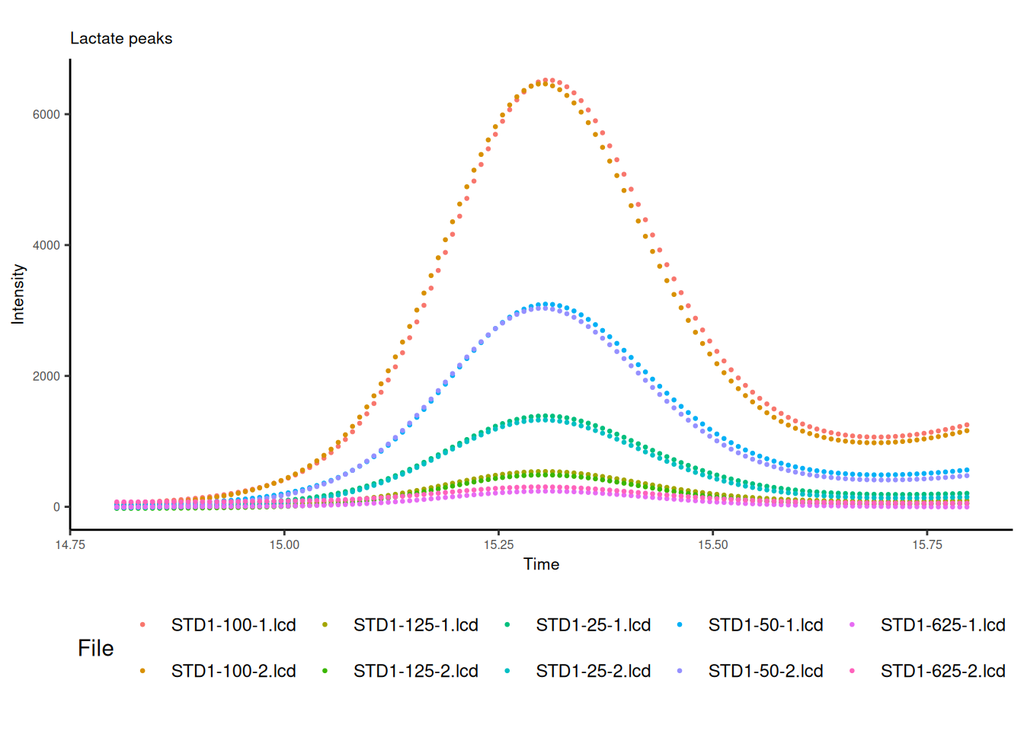

Peak areas of lactate in each of the standards samples.

```r
# plot peaks
 myplot = ggplot(peaks.all, aes(x=Minutes, y=Intensity, group=File, color=File)) +
  ggtitle(paste(Compound, " peaks", sep=""))+
  geom_point(size=0.5) +
  xlab("Time") +
  ylab("Intensity") +
  coord_cartesian(xlim=c(peak.start, peak.end), ylim=c(min(peaks.all$Intensity), max(peaks.all$Intensity)))+
  theme_classic()+
  mytheme;

myplot
```

Plot regressions

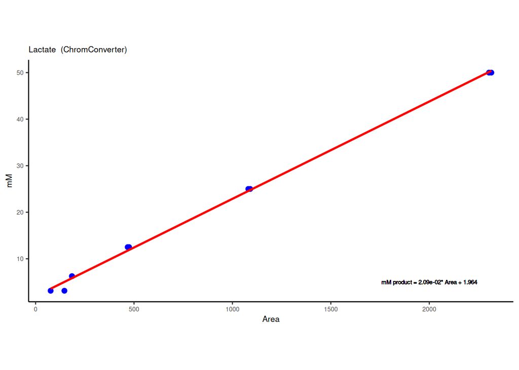

Linear regressions of peak area vs lactate concentration for all standards.

```r
# text placement
text.x = 10e3;
text.y = 50;

# text placement
text.x = 2e3;
text.y = 5;

plot.reg.cc = ggplot(areas.all.concs, aes(x=Area, y=mM))+
  ggtitle(paste(Compound," (ChromConverter)"))+
  geom_point(size=2, color = 'blue') +
  geom_smooth(method=lm, se=FALSE, color='red', width=0.1, formula = y ~ x)+
  xlab("Area") +
  ylab("mM") +
  theme_classic() +
  geom_text(x=text.x, y=text.y, label=regtext.cc, size=2)+
  mytheme;

# print regressions
 bothplots = grid.arrange(plot.reg.cc, ncol = 1);
```

### Glucose

Calc peak areas

```r
# compound parameters
Compound = "Glucose";
peak.start = 10.65;
peak.end = 11.3;

# get the chromatogram peaks and calculate the areas for each sample
peakData = calc_peakAreas(peak.start, peak.end, data.all);
peaks.all = peakData[[1]];
areas.all = peakData[[2]];

# add standard concentrations to peak areas
standards.compound = standards %>%
  filter(Metabolite == Compound);

areas.all.concs = left_join(areas.all, standards.compound, by="File");

areas.all.concs = areas.all.concs %>%
  rename(Area = my.area);
```

Calc regressions

```r
my.lm = lm(mM ~ Area, areas.all.concs);
yint = my.lm$coefficients[1];
myslope = my.lm$coefficients[2];
myslope.text = formatC(myslope, format = "e", digits = 2);

regression.cc = data.frame(Compound, myslope, yint, peak.start, peak.end);
regressions.out = rbind(regressions.out, regression.cc);
regtext.cc = paste("mM product = ", myslope.text, "* Area + ", round(yint, 3), sep="");
```

Plot peaks

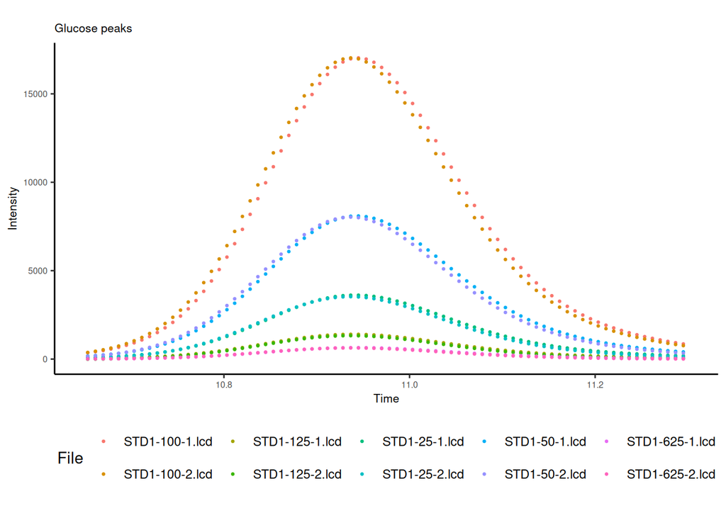

Peak areas of glucose in each of the standards samples.

```r
# plot peaks
 myplot = ggplot(peaks.all, aes(x=Minutes, y=Intensity, group=File, color=File)) +
  ggtitle(paste(Compound, " peaks", sep=""))+
  geom_point(size=0.5) +
  xlab("Time") +
  ylab("Intensity") +
  coord_cartesian(xlim=c(peak.start, peak.end), ylim=c(min(peaks.all$Intensity), max(peaks.all$Intensity)))+
  theme_classic()+
  mytheme;

myplot
```

Plot regressions

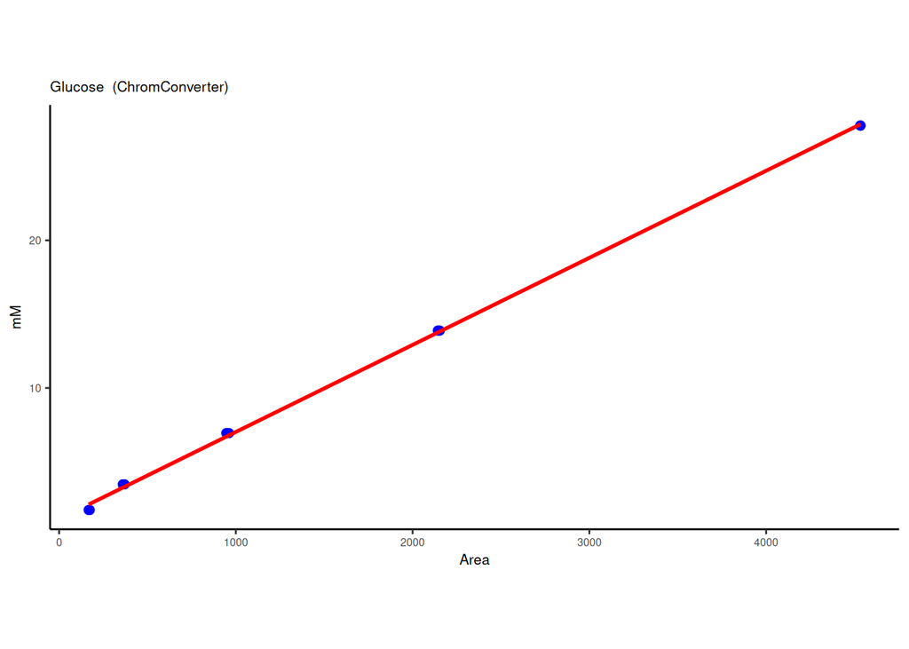

Linear regressions of peak area vs glucose concentration for all standards.

```r
# text placement
text.x = 10e3;
text.y = 5;

plot.reg.cc = ggplot(areas.all.concs, aes(x=Area, y=mM))+
  ggtitle(paste(Compound," (ChromConverter)"))+
  geom_point(size=2, color = 'blue') +
  geom_smooth(method=lm, se=FALSE, color='red', width=0.1, formula = y ~ x)+
  xlab("Area") +
  ylab("mM") +
  theme_classic() +
  geom_text(x=text.x, y=text.y, label=regtext.cc, size=2)+
  mytheme;

# print regressions
 bothplots = grid.arrange(plot.reg.cc, ncol = 1);
```

### Cellobiose

Calc peak areas

```r
# compound parameters
Compound = "Cellobiose";
peak.start = 8.5;
peak.end = 9.5;

# get the chromatogram peaks and calculate the areas for each sample
peakData = calc_peakAreas(peak.start, peak.end, data.all);
peaks.all = peakData[[1]];
areas.all = peakData[[2]];

# add standard concentrations to peak areas
standards.compound = standards %>%
  filter(Metabolite == Compound);

areas.all.concs = left_join(areas.all, standards.compound, by="File");

areas.all.concs = areas.all.concs %>%
  rename(Area = my.area);
```

Calc regressions

```r
my.lm = lm(mM ~ Area, areas.all.concs);
yint = my.lm$coefficients[1];
myslope = my.lm$coefficients[2];
myslope.text = formatC(myslope, format = "e", digits = 2);

regression.cc = data.frame(Compound, myslope, yint, peak.start, peak.end);
regressions.out = rbind(regressions.out, regression.cc);
regtext.cc = paste("mM product = ", myslope.text, "* Area + ", round(yint, 3), sep="");
```

Plot peaks

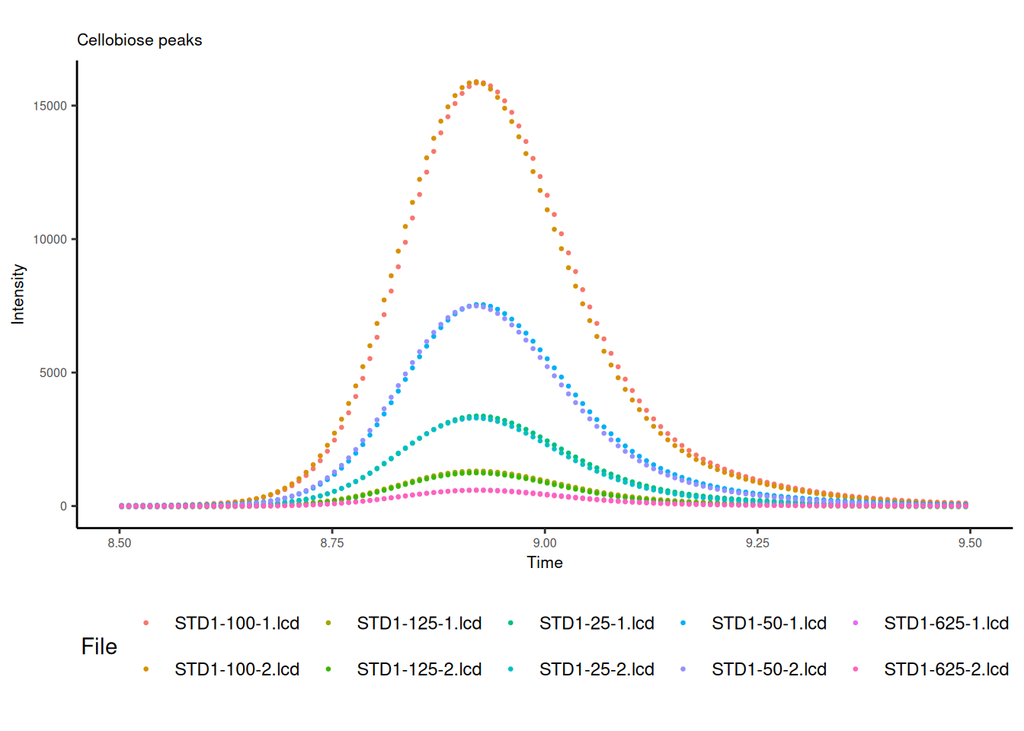

Peak areas of cellobiose in each of the standards samples.

```r
# plot peaks
 myplot = ggplot(peaks.all, aes(x=Minutes, y=Intensity, group=File, color=File)) +
  ggtitle(paste(Compound, " peaks", sep=""))+
  geom_point(size=0.5) +
  xlab("Time") +
  ylab("Intensity") +
  coord_cartesian(xlim=c(peak.start, peak.end), ylim=c(min(peaks.all$Intensity), max(peaks.all$Intensity)))+
  theme_classic()+
  mytheme;

myplot
```

Plot regressions

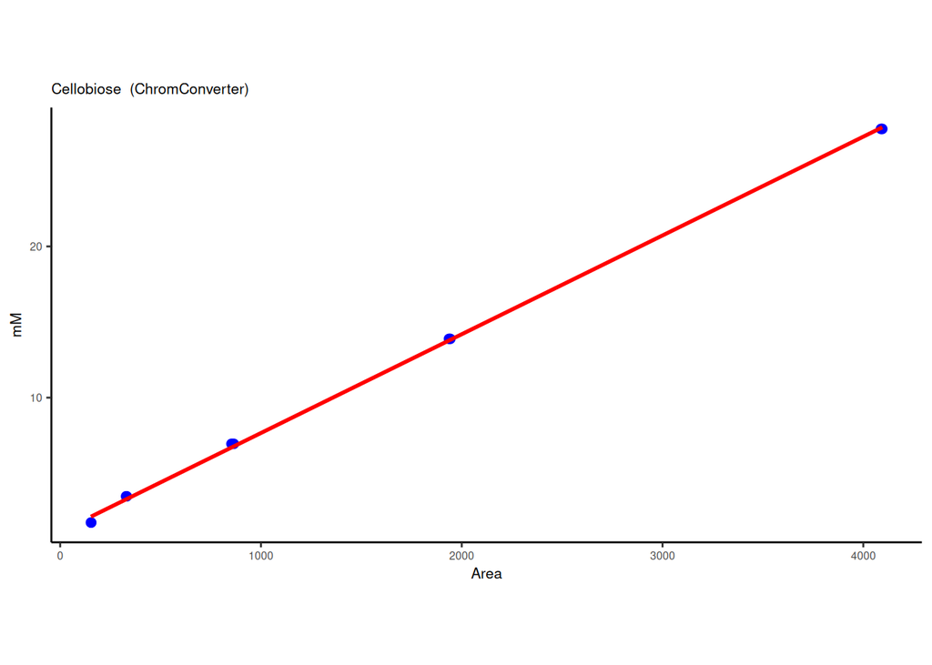

Linear regressions of peak area vs cellobiose concentration for all standards.

```r
# text placement
text.x = 8e3;
text.y = 5;

plot.reg.cc = ggplot(areas.all.concs, aes(x=Area, y=mM))+
  ggtitle(paste(Compound," (ChromConverter)"))+
  geom_point(size=2, color = 'blue') +
  geom_smooth(method=lm, se=FALSE, color='red', width=0.1, formula = y ~ x)+
  xlab("Area") +
  ylab("mM") +
  theme_classic() +
  geom_text(x=text.x, y=text.y, label=regtext.cc, size=2)+
  mytheme;

# print regressions
 bothplots = grid.arrange(plot.reg.cc, ncol = 1);
```

## Output regression parameters

```r
table.regression = kable(regressions.out, caption = "Table: regression parameters for each metabolite.");
table.regression
```

Table: regression parameters for each metabolite.

|  | Compound | myslope | yint | peak.start | peak.end |
| --- | --- | --- | --- | --- | --- |
| Area | Acetate | 0.0373619 | 0.9798497 | 17.70 | 18.70 |
| Area1 | Ethanol | 0.0572155 | 5.8020664 | 25.75 | 27.25 |
| Area2 | Lactate | 0.0209147 | 1.9640100 | 14.80 | 15.80 |
| Area3 | Glucose | 0.0058974 | 1.1258853 | 10.65 | 11.30 |
| Area4 | Cellobiose | 0.0065340 | 1.1267501 | 8.50 | 9.50 |

```r
write.table(regressions.out, file = table.out, row.names=FALSE, sep="\t")
```